# Lecture 5: Percentiles, Quartiles and Standard Deviations (POLS 3316 - Statistics for Political Scientists)

Tom Hanna

### Measures of Dispersion Continued

Yesterday we covered variance and I told you that standard deviation is the square root of variance. Why do we care?

Suppose we have two companies, A and B, with the same mean salary - $70,000.

Company A has a variance of 2,500.

Company B has a variance of 40,000.

In most companies entry level workers with no seniority are paid the least and workers with the most seniority are paid the most.

Assume you have the same chance of getting hired at Company A or Company B?

As a new college graduate starting at one of these companies, which would you prefer to work for?

[Adapted from: https://www.dummies.com/article/academics-the-arts/math/statistics/why-standard-deviation-is-an-important-statistic-169731/](https://www.dummies.com/article/academics-the-arts/math/statistics/why-standard-deviation-is-an-important-statistic-169731/)

The answer is pretty obvious, but just working with the variance it’s also overblown. Why?

Because in variance the units are squared!

By taking the square root of the variance, we get back to the original unit of measure. So, in the example:

Company A has a standard deviation of 50.

Company B has a standard deviation of 200.

One standard deviation from the mean is $69,950. Because of some rules we’ll discuss more later, 99.7% of employees are within 3 standard deviations of the mean.

So, 99.7% of Company A employees make between $69,850 and $70,150 a year.

99.7% of Company B employees make between $69,400 and $70,600 a year.

Let’s up those variances a bit and look at this graphically:

Company A - variance 2,500 Company B - variance 250,000

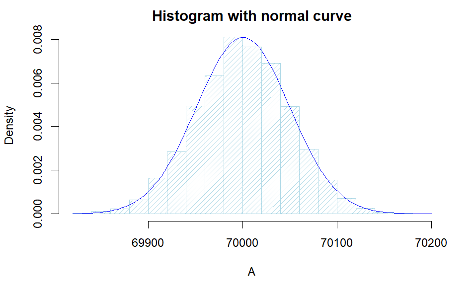

```r
#Simulating data for company A and B from the mean and standard deviation
set.seed(1234)
A <- rnorm(n=10000, mean=70000, sd=50)
B <- rnorm(n=10000, mean=70000, sd=500)

A_mean<-mean(A)
stdA<-sqrt(var(A))
B_mean<-mean(B)
stdB<-sqrt(var(B))

hist(A, density=20, prob=TRUE,
main="Histogram with normal curve", col = "lightblue")
curve(dnorm(x, mean=A_mean, sd=stdA), col = "blue", add=TRUE)
```

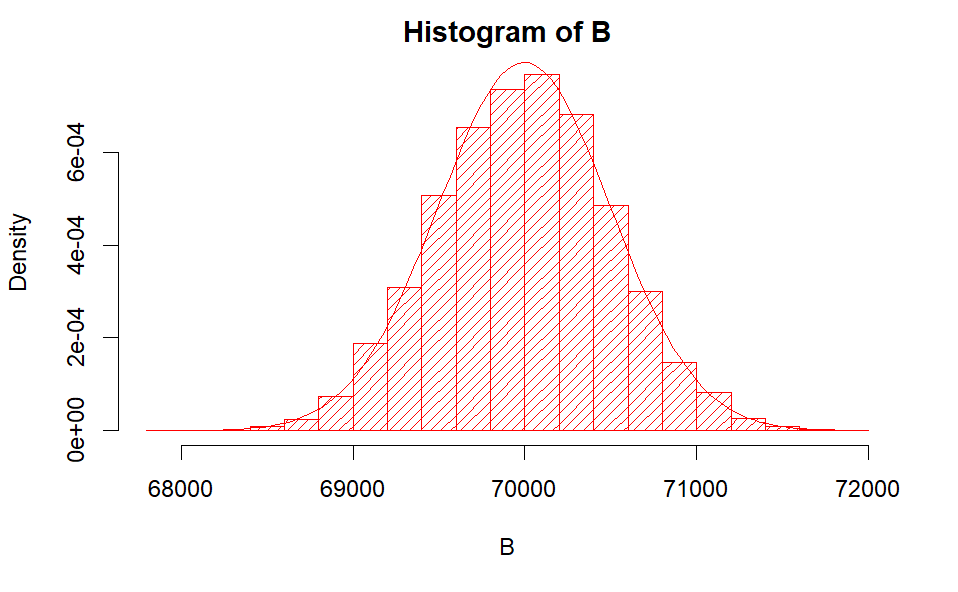

```r
hist(B, density=20, prob=TRUE, col = "red")
curve(dnorm(x, mean=B_mean, sd=stdB), col = "red", add=TRUE)
```